# Stats 369 Assignment 3

Hasnain Cheena

07/10/2020

```r
load("spam.rda")

#create feature-label df
word.df = data.frame(wordmatrix)
col.names = make.names(names(word.df))
names(word.df) = col.names
spam.df = cbind(word.df, df['is_spam'])
```

## Task 1

Use rpart to fit and prune (if necessary) a tree predicting spam/non-spam from the common word counts in the wordmatrix matrix. Report the accuracy with a confusion matrix. Plot the fitted tree (without all the labels) and comment on its shape.

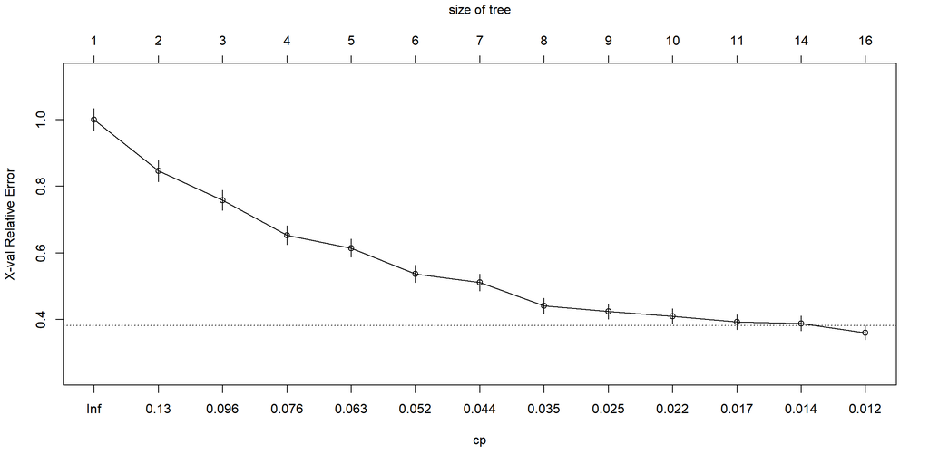

```r
spam.tree = rpart(factor(is_spam) ~. , data=spam.df)

#plot cp to see if pruning is needed
plotcp(spam.tree)
```

```r
printcp(spam.tree)
```

```
##
## Classification tree:
## rpart(formula = factor(is_spam) ~ ., data = spam.df)
##
## Variables actually used in tree construction:
##  [1] w_awarded    w_Call       w_claim      w_collection w_Free
##  [6] w_FREE       w_me         w_mobile     w_PO         w_Reply
## [11] w_service    w_STOP       w_Text       w_Txt        w_www
##
## Root node error: 747/5574 = 0.13402
##
## n= 5574
##
##          CP nsplit rel error  xerror     xstd
## 1  0.153949      0   1.00000 1.00000 0.034048
## 2  0.104418      1   0.84605 0.84605 0.031689
## 3  0.088353      2   0.74163 0.75770 0.030188
## 4  0.065596      3   0.65328 0.65328 0.028248
## 5  0.060241      4   0.58768 0.61446 0.027474
## 6  0.044177      5   0.52744 0.53681 0.025825
## 7  0.042838      6   0.48327 0.51138 0.025252
## 8  0.028112      7   0.44043 0.44043 0.023554
## 9  0.022758      8   0.41232 0.42436 0.023147
## 10 0.021419      9   0.38956 0.40964 0.022766
## 11 0.014279     10   0.36814 0.39224 0.022304
## 12 0.013387     13   0.32530 0.38822 0.022196
## 13 0.010000     15   0.29853 0.36011 0.021420
```

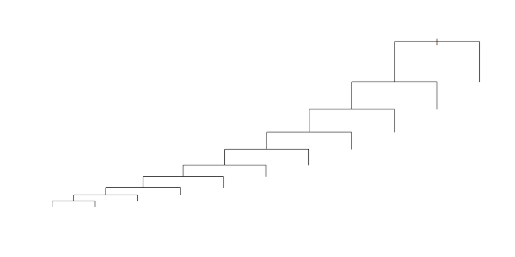

```r
#prune tree
spam.tree.pruned = prune(spam.tree, cp=0.021)

#plot pruned tree
plot(spam.tree.pruned)
```

Furthermore, looking at a plot of the tree you can see that at every split the tree branches in the same direction. Each branch further partitions the feature space (number of occurrences of each common word) into regions.Then prediction of a message into spam/not spam occurs by selecting the mode of the region.

```r
#confusion matrix
y_pred_prob = predict(spam.tree.pruned)
max_idx <- apply(y_pred_prob, 1, which.max)
y_pred = colnames(y_pred_prob)[max_idx]
conf_matrix = with(spam.df, table(actual=is_spam, predicted=y_pred))
conf_matrix
```

```
##        predicted
## actual  FALSE TRUE
##   FALSE  4780   47
##   TRUE    228  519
```

## Task 2

Compute $y_i$, $n_i$ and $e_i$ per word.

```r
#Find Yi and Ni for calculating word occurrences
common_word_occurance = data.frame()
not_spam_entries.df = word.df[spam.df$is_spam == FALSE, ]
spam_entries.df = word.df[spam.df$is_spam == TRUE, ]
common_words_fixed = names(word.df)
for (word in common_words_fixed){

  ni = sum(not_spam_entries.df[, word])
  yi = sum(spam_entries.df[, word])

  ei = log(yi + 1) - log(ni + 1) #evidence

  row = c(word, yi, ni, ei)
  common_word_occurance = rbind(common_word_occurance, row)

}
names(common_word_occurance) = c("word", "yi", "ni", "ei")

head(common_word_occurance)
```

```
##    word   yi    ni                ei
## 1    w_ 2266 11605 -1.63306483424302
## 2   w_.   56   163 -1.05681515998965
## 3  w_..    0    21 -3.09104245335832
## 4 w_..1    1    58 -3.38439026334577
## 5 w_..2    1    37 -2.94443897916644
## 6 w_..3   98    13  1.95606252051933
```

Compute $e_i$ per message.

```r
#compute total evidence
naive_bayes_classification = data.frame()
for (idx in 1:nrow(word.df)){
  message = word.df[idx, ]
  total_ei = as.numeric(message) %*% as.numeric(common_word_occurance$ei)
  naive_bayes_classification = rbind(naive_bayes_classification, data.frame(message_id = idx,
                                                                            total_ei = c(total_ei)))
}

head(naive_bayes_classification)
```

```
##   message_id  total_ei
## 1          1 -38.42126
## 2          2 -22.59465
## 3          3  11.40284
## 4          4 -36.83491
## 5          5 -34.69777
## 6          6 -39.33583
```

#### Find Threshold

First a coarse sweep was performed to generally find good threshold values. Then a much finer search was performed using the coarse search results to find the actual threshold.

The constraint “the proportion of spam predicted is the same as the proportion observed” was interpreted using the following approach:

$$\frac{TP + FP}{number \space of \space observations} = \frac{actual \space spam}{number \space of \space observations}$$
$$TP + FP = actual \space spam$$

```r
#proportion of observed spam
actual_spam = sum(spam.df$is_spam == TRUE)


#brief check - choose threshold
threshold_values = seq(round(min(naive_bayes_classification$total_ei),0), round(max(naive_bayes_classification$total_ei),0))
#perform classification - TRUE if spam and FALSE if not spam
threshold.df = data.frame()
for (threshold in threshold_values){
  num_spam_pred = sum(naive_bayes_classification$total_ei < threshold)
  threshold.df = rbind(threshold.df, c(threshold, num_spam_pred))
}
names(threshold.df) = c("threshold", "number of spam predicted")

c("actual spam" = actual_spam)
```

```
## actual spam
##         747
```

```r
threshold.df[347:348, ]
```

```
##     threshold number of spam predicted
## 347       -48                      733
## 348       -47                      766
```

From the brief search above you can see threshold values of -47 and -48 seem to predict approximately the same amount of actual spam. In the next step we will fine tune the search to find the right threshold value.

```r
#more fine tuned check - choose threshold
threshold_values = seq(-48, -47, 0.001)
#perform classification - TRUE if spam and FALSE if not spam
threshold.df = data.frame()
for (threshold in threshold_values){
  num_spam_pred = sum(naive_bayes_classification$total_ei < threshold)
  threshold.df = rbind(threshold.df, c(threshold, num_spam_pred))
}
names(threshold.df) = c("threshold", "number of spam predicted")

threshold.df[threshold.df$`number of spam predicted` == actual_spam, ]
```

```
##     threshold number of spam predicted
## 376   -47.625                      747
```

Thus a threshold of -47.625 produces the condition where the proportion of spam predicted is the same as the proportion observed.

In the next step produce a confusion matrix for the Naive Bayes classifier.

```r
threshold = -47.625
naive_bayes_classification$is_spam = naive_bayes_classification$total_ei < threshold

#confusion matrix
conf_matrix = table(actual=spam.df$is_spam, predicted=naive_bayes_classification$is_spam)
conf_matrix
```

```
##        predicted
## actual  FALSE TRUE
##   FALSE  4085  742
##   TRUE    742    5
```

## Task 3

Read the description at the UCI archive of how the dataset was constructed. Why is spam/non-spam accuracy likely to be higher with this dataset than in real life? What can you say about the generalisability of the classifier to particular populations of text users?

#### Generalisability

A large subset of the corpus originates from Singapore thus containing Singaporean English. Hence the classifier produced may work well in Singapore but may not generalise well to other regions of the world because the way we speak/write English differs.

#### Spam/Non-spam accuracy likely to be higher with this dataset than in real-life?

The dataset was published in 2012 which is 8 years ago. The content of spam/non-spam messages has changed quite drastically since then. Therefore, the classifier will show a higher accuracy with the dataset than when used in real-life in 2020.